# **Day 2: Record Linkage and Statistical Matching**

Author

Camilla Salvatore

# 1 **Introduction**

This material is part of the GESIS workshop “**Survey Data Integration: Combining (Non)probability, Administrative, and Digital Trace Data**”.

Click on the link to download the data.

In this practical session we learn how to implement Record Linkage and Statistical matching.

# 2 **Record Linkage**

In this practical session we learn how to link records that belong to the same person when there is no unique identifier. It is divided into three parts:

1. Comparing strings: Levenshtein, Jaro–Winkler and q-grams (the “Try it out!” exercises in the slides);
2. Probabilistic record linkage with **fastLink**: a solved tutorial and exercises;
3. Extra exercises.

**Objectives**

- Compute and interpret string similarities between names
- Link two files with exact matching and with probabilistic record linkage (Fellegi–Sunter model estimated with EM)
- Evaluate a linkage with precision, recall measures, and see how the settings change the result

**Note**

- Install the packages once: `install.packages(c("stringdist", "fastLink", "RecordLinkage"))`. If the CRAN version of fastLink gives problems, install it from GitHub: `remotes::install_github("kosukeimai/fastLink")`
- Put the data files (`fileA.csv` and `fileB.csv`) in your working directory, or in the folder given by `data_dir` in the header of this file

## 2.1 **Comparing strings**

Before two records can be compared, we need to decide when two values “agree”. For names this is not obvious: *MAIER* and *MEYER* may be the same surname written in two ways. String comparators measure how similar two strings are, usually on a scale from 0 (nothing in common) to 1 (identical).

We use the package **stringdist** (van der Loo, 2014). `stringdist()` returns a **distance** (0 = identical) and `stringsim()` a **similarity** (1 = identical).

```r
library(stringdist)
```

### 2.1.1 **Levenshtein distance**

#### 2.1.1.1 **Solved example**

The Levenshtein distance $d(a, b)$ is the minimum number of insertions, deletions and substitutions needed to turn $a$ into $b$. To turn *ACRO* into *ASCHERI* we need 3 insertions (S, H, E) and 1 substitution (O → I), so $d = 4$.

The similarity divides the distance by the length of the **longer** string: $1 - d / \max(|a|, |b|) = 1 - 4/7 = 0.43$.

**Click here to show the code (but first try it yourself!)**

```r
stringdist("ACRO", "ASCHERI", method = "lv")
```

```
[1] 4
```

```r
stringsim("ACRO", "ASCHERI", method = "lv")
```

```
[1] 0.4285714
```

```r
1 - 4 / max(nchar("ACRO"), nchar("ASCHERI"))
```

```
[1] 0.4285714
```

#### 2.1.1.2 **Exercises**

1. **Levenshtein for surname pairs:** For the pairs below, compute the Levenshtein distance, the normalized distance $d / \max(|a|, |b|)$ and the similarity. Compute the similarity in two ways: with `stringsim()` and with `levenshteinSim()` from the **RecordLinkage** package. Do you get the same values?

```r
pairs <- data.frame(
  name1 = c("MAIER", "SALVATORE", "SCHUTE", "VERSTAPPEN", "VANBERGEN", "MARTHA"),
  name2 = c("MEYER", "SALVATORI", "SCHULTSE", "VARSTAPEN", "BERGEN", "MARHTA")
)
```

**Click here to show the solution**

```r
library(RecordLinkage)

pairs$distance <- stringdist(pairs$name1, pairs$name2, method = "lv")
pairs$max_length <- pmax(nchar(pairs$name1), nchar(pairs$name2))
pairs$normalized_distance <- pairs$distance / pairs$max_length

pairs$similarity_stringdistlv   <- stringsim(pairs$name1, pairs$name2, method = "lv")
pairs$similarity_RecordLinkagelv <- levenshteinSim(pairs$name1, pairs$name2)

pairs[, -4]
```

```
       name1     name2 distance normalized_distance similarity_stringdistlv
1      MAIER     MEYER        2           0.4000000               0.6000000
2  SALVATORE SALVATORI        1           0.1111111               0.8888889
3     SCHUTE  SCHULTSE        2           0.2500000               0.7500000
4 VERSTAPPEN VARSTAPEN        2           0.2000000               0.8000000
5  VANBERGEN    BERGEN        3           0.3333333               0.6666667
6     MARTHA    MARHTA        2           0.3333333               0.6666667
  similarity_RecordLinkagelv
1                  0.6000000
2                  0.8888889
3                  0.7500000
4                  0.8000000
5                  0.6666667
6                  0.6666667
```

The two functions give the same similarity, because both use $1 - d / \max(|a|, |b|)$. Note that some texts divide by the **sum** of the lengths, or by the average length, so the numbers are not always comparable across sources.

*MARTHA* and *MARHTA* have distance 2: Levenshtein counts a swap of two letters as two substitutions. Typing errors like this are frequent in names, which is one reason for the Jaro–Winkler comparator.

### 2.1.2 **Jaro and Jaro–Winkler**

The Jaro similarity counts the characters that the two strings have in common (within a matching window) and how many of them are out of order (transpositions):

$$J(s_1, s_2) = \frac{1}{3}\left(\frac{m}{|s_1|} + \frac{m}{|s_2|} + \frac{m - t}{m}\right)$$

where $m$ is the number of matching characters and $t$ is half the number of matching characters in a different order. Winkler adds a bonus for an agreeing beginning, because errors are rarer at the start of names: $JW = J + \ell \, p \, (1 - J)$, with $\ell$ the length of the common prefix (at most 4) and $p = 0.1$.

#### 2.1.2.1 **Solved example**

*MARTHA* and *MARHTA* have $m = 6$ common characters and one transposition (T/H), so $t = 1$ and $J = \frac{1}{3}\left(1 + 1 + \frac{5}{6}\right) = 0.944$. The common prefix *MAR* gives $\ell = 3$, so $JW = 0.944 + 3 \cdot 0.1 \cdot 0.056 = 0.961$.

**Click here to show the code (but first try it yourself!)**

```r
a <- "MARTHA"; b <- "MARHTA"
jaro <- stringsim(a, b, method = "jw", p = 0)
jw   <- stringsim(a, b, method = "jw", p = 0.1)
dist <- stringdist(a, b, method = "jw", p = 0.1)
round(c(Jaro = jaro, JaroWinkler = jw, JW_distance = dist), 6)
```

```
       Jaro JaroWinkler JW_distance
   0.944444    0.961111    0.038889
```

#### 2.1.2.2 **Exercises**

1. **Jaro and Jaro–Winkler for the surname pairs:** Compute both similarities for the pairs above. Which pairs gain most from the Winkler correction, and why does *VANBERGEN*/*BERGEN* get none? Compare with the Levenshtein similarities: which comparator is more tolerant of the typing error in *MARTHA*/*MARHTA*?

**Click here to show the solution**

```r
pairs$jaro <- stringsim(pairs$name1, pairs$name2, method = "jw", p = 0)
pairs$jaro_winkler <- stringsim(pairs$name1, pairs$name2, method = "jw", p = 0.1)
round(pairs[, c("jaro", "jaro_winkler")], 3)
```

```
   jaro jaro_winkler
1 0.733        0.760
2 0.926        0.956
3 0.917        0.950
4 0.813        0.832
5 0.722        0.722
6 0.944        0.961
```

- The Winkler bonus $\ell \, p \, (1 - J)$ grows with the length of the common beginning and with the room left for improvement ($1 - J$). The largest increases are for *SCHUTE*/*SCHULTSE* (+0.033) and *SALVATORE*/*SALVATORI* (+0.030). *VANBERGEN* and *BERGEN* start with different letters, so the prefix length is 0 and $JW = J$.
- For *MARTHA*/*MARHTA*, Jaro–Winkler gives 0.961, Levenshtein only 0.667: Jaro counts a swap of two letters as a small error.
- With fastLink’s default cut-offs (agreement if $JW \ge 0.94$, partial agreement if $JW \ge 0.88$), *SALVATORI*, *SCHULTSE* and *MARHTA* would count as **agreement**, while *MEYER*, *VARSTAPEN* and *BERGEN* would count as **disagreement**.

### 2.1.3 **q-grams and the Jaccard similarity**

A q-gram is a substring of $q$ consecutive characters. With $q = 2$ (bigrams), *JANSEN* becomes {JA, AN, NS, SE, EN}. The Jaccard similarity is the share of distinct bigrams that the two strings have in common:

$$J(A, B) = \frac{|A \cap B|}{|A \cup B|}, \qquad D_J(A, B) = 1 - J(A, B)$$

#### 2.1.3.1 **Solved example**

*JANSEN* and *JANSSEN* share 5 bigrams (JA, AN, NS, SE, EN) out of 6 distinct bigrams (the extra one is SS), so $J = 5/6 = 0.83$ and the Jaccard distance is $0.17$.

**Click here to show the code (but first try it yourself!)**

```r
qgrams("JANSEN", "JANSSEN", q = 2)
```

```
   JA NS SE SS AN EN
V1  1  1  1  0  1  1
V2  1  1  1  1  1  1
```

```r
stringsim("JANSEN", "JANSSEN", method = "jaccard", q = 2)
```

```
[1] 0.8333333
```

```r
stringdist("JANSEN", "JANSSEN", method = "jaccard", q = 2)
```

```
[1] 0.1666667
```

#### 2.1.3.2 **Exercises**

1. **Jaccard for the surname pairs:** Compute the Jaccard similarity and dissimilarity (with $q = 2$) for the pairs above. Why is the similarity so low for *MAIER*/*MEYER* and for *MARTHA*/*MARHTA*?

**Click here to show the solution**

```r
pairs$jaccard_sim  <- stringsim(pairs$name1, pairs$name2, method = "jaccard", q = 2)
pairs$jaccard_dist <- stringdist(pairs$name1, pairs$name2, method = "jaccard", q = 2)
round(pairs[, c("jaro_winkler", "jaccard_sim", "jaccard_dist")], 3)
```

```
  jaro_winkler jaccard_sim jaccard_dist
1        0.760       0.143        0.857
2        0.956       0.778        0.222
3        0.950       0.333        0.667
4        0.832       0.545        0.455
5        0.722       0.625        0.375
6        0.961       0.250        0.750
```

```r
qgrams("MAIER", "MEYER", q = 2)
```

```
   MA ME YE AI IE ER EY
V1  1  0  0  1  1  1  0
V2  0  1  1  0  0  1  1
```

In short names, a single changed letter destroys two bigrams. *MAIER* and *MEYER* share only *ER* (1 of 7 distinct bigrams, 0.143). The swap in *MARTHA*/*MARHTA* changes three bigrams (RT, TH, HA vs RH, HT, TA), so the similarity is only 0.25. q-grams work better for **longer** strings, such as addresses or full names, and for blocking (e.g. indexing records by their bigrams).

### 2.1.4 **Which comparator should I use?**

**Summary**

- **Exact comparison**: codes, dates, sex – anything where a near agreement has no meaning.
- **Levenshtein**: typing errors in longer strings; it counts each edit the same.
- **Jaro–Winkler**: short strings such as first and last names; tolerant of transpositions, gives extra weight to the first letters. It is the default in fastLink.
- **q-grams**: longer strings (addresses).
- **Numeric distance**: years, ages, coordinates, with a tolerance.

## 2.2 **Probabilistic record linkage with fastLink**

In this part, we show how to use fastLink to implement probabilistic record linkage.

### 2.2.1 **The data**

We use **RLdata10000**, a synthetic data set of 10,000 German person records that comes with the RecordLinkage package (Sariyar & Borg, 2010). It contains 9,000 persons; **1,000 of them appear twice**, and the second record contains errors (typos in names, wrong digits in the dates of birth). The true person identifier `ent_id` is known, so we can **evaluate** the linkage. It is never used for matching.

We split the data into two files, **file A** and **file B**, with 5,000 records each, so that each of the 1,000 duplicated persons appears once in A and once in B. The data we provide are:

1. **File A**: `fileA.csv` – 5,000 records
2. **File B**: `fileB.csv` – 5,000 records; 1,000 persons are also in file A (the **true overlap**)

We consider the following variables:

- `fname_c1` : First name (first component)
- `fname_c2` : First name (second component; mostly missing)
- `lname_c1` : Last name (first component)
- `lname_c2` : Last name (second component; mostly missing)
- `by`, `bm`, `bd` : Year, month and day of birth
- `ent_id` : True person identifier (for evaluation only)

#### 2.2.1.1 **Preliminary analyses**

1. **Before starting, load the necessary R packages and the data:**

```r
library(fastLink)

data_dir <- params$data_dir   ## folder containing the data files
fileA <- read.csv(file.path(data_dir, "fileA.csv"))
fileB <- read.csv(file.path(data_dir, "fileB.csv"))

## read.csv() reads the birth year as integer; numeric.match in fastLink needs class numeric
fileA$by <- as.numeric(fileA$by)
fileB$by <- as.numeric(fileB$by)

## The EM algorithm in fastLink starts from random values: fix the seed to get
## the same results as in this document (if you run the code in the same order)
set.seed(1234)
```

**Task:** Familiarize yourself with the datasets. How many records are in both files? How many values are missing in the second name components?

**Click here to show the solution**

```r
fields <- c("fname_c1", "lname_c1", "by", "bm", "bd")
c(nrow(fileA), nrow(fileB))
```

```
[1] 5000 5000
```

```r
head(fileA[, c(fields, "ent_id")], 3)
```

```
  fname_c1   lname_c1   by bm bd ent_id
1   MARTIN    SCHWARZ 1967  2 17   2560
2  HERBERT ZIMMERMANN 1961 11  6   3892
3     HANS    SCHMITT 1945  8 14    329
```

```r
true_overlap <- sum(fileA$ent_id %in% fileB$ent_id)
true_overlap
```

```
[1] 1000
```

```r
colMeans(is.na(fileA[, c("fname_c2", "lname_c2")]))
```

```
fname_c2 lname_c2
  0.9350   0.9894
```

1,000 persons are in both files. The second name components are missing for about 94% (first name) and 99% (last name) of the records, so we use only the first components.

2. **What do the errors look like?** Merge the two files by `ent_id` and look at the first true pairs. Which variables differ?

**Click here to show the solution**

```r
pairs_true <- merge(fileA, fileB, by = "ent_id", suffixes = c(".A", ".B"))
head(pairs_true[, c("fname_c1.A", "fname_c1.B", "lname_c1.A", "lname_c1.B",
                    "by.A", "by.B", "bm.A", "bm.B", "bd.A", "bd.B")], 4)
```

```
  fname_c1.A fname_c1.B lname_c1.A lname_c1.B by.A by.B bm.A bm.B bd.A bd.B
1       PAUL       PAUL  SCHAECFER   SCHAEFER 1942 1942    7    7    2    2
2    HERBERT    HERBERT   ALBRECHT   ALBRECHT 1985 1985   12   12    8   15
3     MARKUS    MARKGUS    NEUMANN    NEUMANN 1948 1948    7    7   31   31
4   BERNHARD   BERNHARD    MUELLER    MUELLER 1951 1951    1    6   27   27
```

Typical errors are typos in the names (SCHAECFER/SCHAEFER, MARKUS/MARKGUS) and wrong birth days or months. In 961 of the 1,000 true pairs exactly **one** variable differs; in 31 pairs two or three variables differ, and 8 pairs are identical.

### 2.2.2 **Exact matching**

#### 2.2.2.1 **Exercises**

1. **Exact merge:** Link the two files with `merge()` on first name, last name and date of birth. How many links do you find? How many are correct, and how many true matches are missed?

**Click here to show the solution**

```r
exact <- merge(fileA, fileB, by = fields)
nrow(exact)
```

```
[1] 8
```

```r
TP <- sum(exact$ent_id.x == exact$ent_id.y)
c(TP = TP, FP = nrow(exact) - TP, FN = true_overlap - TP)
```

```
 TP  FP  FN
  8   0 992
```

The exact merge finds only **8 of the 1,000** true matches. All 8 are correct (precision = 1), but the recall is 0.008: one typo or one wrong digit is enough to break the linkage process.

### 2.2.3 **An evaluation function**

To compare the methods, we write a function that counts true positives (linked pairs with the same `ent_id`), false positives and false negatives, and computes precision, recall and F1. It works for any object with the indices of the linked records in `$matches$inds.a` and `$matches$inds.b`, as returned by fastLink.

```r
evaluate <- function(out) {
  ia <- out$matches$inds.a; ib <- out$matches$inds.b
  TP <- sum(fileA$ent_id[ia] == fileB$ent_id[ib])
  FP <- length(ia) - TP
  FN <- true_overlap - TP
  precision <- TP / (TP + FP); recall <- TP / (TP + FN)
  round(c(TP = TP, FP = FP, FN = FN, precision = precision,
          recall = recall,
          F1 = 2 * precision * recall / (precision + recall)), 3)
}
```

**Definitions**

Each pair of records (one from A, one from B) is either a **true match** (same `ent_id`) or a **non-match**, and the method either **links** it or does not:

|  | True match | Non-match |
| --- | --- | --- |
| **Linked** | True positive (TP) | False positive (FP) |
| **Not linked** | False negative (FN) | True negative (TN) |

- **TP**: a linked pair that really belongs to the same person (a correct link).
- **FP**: a linked pair of two different persons (a **false link**).
- **FN**: a pair of records of the same person that was not linked (a **missed link**). Here FN = 1,000 − TP.
- **Precision** $= \frac{TP}{TP + FP}$: of all the links we made, what share is correct?
- **Recall** $= \frac{TP}{TP + FN}$: of all the true matches, what share did we find?
- **F1** $= \frac{2 \cdot \text{precision} \cdot \text{recall}}{\text{precision} + \text{recall}}$: a summary of both; it is high only if precision **and** recall are high.

**Note**

With real data the true identifier is unknown: you would evaluate the linkage on a sample of pairs checked by hand (clerical review).

### 2.2.4 **Linking with fastLink**

#### 2.2.4.1 **Solved example**

`fastLink()` compares every record in file A with every record in file B (here 5,000 × 5,000 = 25 million pairs), builds the agreement pattern of each pair, estimates the Fellegi–Sunter model with the EM algorithm, and returns the pairs whose posterior match probability is above `threshold.match` (default 0.85).

**Click here to show the code (but first try it yourself!)**

```r
out <- fastLink(dfA = fileA, dfB = fileB,
                varnames = c("fname_c1", "lname_c1", "by", "bm", "bd"),
                stringdist.match = c("fname_c1", "lname_c1"),
                partial.match    = c("fname_c1", "lname_c1"),
                cut.a = 0.94, cut.p = 0.84)
```

[output not shown]

The main arguments:

- `varnames` : variables used for matching (they must have the same names in both files);
- `stringdist.match` : variables compared with a string similarity (Jaro–Winkler by default, see `stringdist.method`);
- `partial.match` : variables with three levels: agreement (2), partial agreement (1) and disagreement (0);
- `cut.a`, `cut.p` : similarity needed for agreement and for partial agreement (defaults 0.94 and 0.88; we use 0.84 for partial agreement);
- numeric variables (`by`, `bm`, `bd`) are compared **exactly**, unless they are listed in `numeric.match`.

**What fastLink returns**

**Click here to show the code (but first try it yourself!)**

```r
names(out)
```

```
[1] "matches"   "EM"        "patterns"  "posterior" "nobs.a"    "nobs.b"
```

```r
nrow(out$matches)
```

```
[1] 1207
```

```r
head(out$matches, 3)
```

```
  inds.a inds.b
1   2178      8
2    328     10
3   1490     14
```

```r
round(head(out$posterior, 3), 3)
```

```
[1] 0.988 0.878 0.878
```

```r
linked <- getMatches(dfA = fileA, dfB = fileB, fl.out = out)
linked$posterior <- round(linked$posterior, 3)
head(linked[, c("fname_c1", "lname_c1", "by", "bm", "bd",
                "gamma.1", "gamma.2", "gamma.3", "gamma.4", "gamma.5",
                "posterior")], 4)
```

```
     fname_c1 lname_c1   by bm bd gamma.1 gamma.2 gamma.3 gamma.4 gamma.5
2178   STEFAN  RICHTER 1946  3 22       2       2       0       2       2
328  THORSTEN    LANGE 1980  7 29       2       2       0       0       2
1490 GUENTHER  MUELLER 1935  9 17       2       2       0       0       2
1730  JOACHIM    KUEHN 1994 11 71       2       2       2       2       0
     posterior
2178     0.988
328      0.878
1490     0.878
1730     0.996
```

- `matches` : row numbers of the linked records in file A (`inds.a`) and file B (`inds.b`);
- `posterior` : estimated probability that the pair is a match;
- `EM` : the estimated parameters ($\lambda$, $m$, $u$) and the agreement patterns;
- `getMatches()` returns the linked data, with the agreement pattern (`gamma.1` = first name, …, `gamma.5` = birth day) of each pair.

fastLink declares 1,207 matches. Each record is linked to at most one record in the other file (`dedupe.matches = TRUE` by default).

**How good is the linkage?**

**Click here to show the code (but first try it yourself!)**

```r
evaluate(out)
```

```
       TP        FP        FN precision    recall        F1
  997.000   210.000     3.000     0.826     0.997     0.903
```

```r
## Some false links
ok <- fileA$ent_id[out$matches$inds.a] == fileB$ent_id[out$matches$inds.b]
fp <- out$matches[!ok, ][1:4, ]
cbind(fileA[fp$inds.a, fields], fileB[fp$inds.b, fields])
```

```
     fname_c1  lname_c1   by bm bd  fname_c1  lname_c1   by bm bd
328  THORSTEN     LANGE 1980  7 29  THORSTEN     LANGE 1965  3 29
1490 GUENTHER   MUELLER 1935  9 17  GUENTHER   MUELLER 1994 11 17
797   GERHARD   SCHMITT 2000  5 22   GERHARD   SCHMITT 2000  1 31
4385  CHRISTA SCHNEIDER 1954 10  6 CHRISTIAN SCHROEDER 1961 10  6
```

|  | Links | TP | FP | FN | Precision | Recall | F1 |
| --- | --- | --- | --- | --- | --- | --- | --- |
| Exact merge | 8 | 8 | 0 | 992 | 1.000 | 0.008 | 0.016 |
| fastLink | 1,207 | 997 | 210 | 3 | 0.826 | 0.997 | 0.903 |

fastLink finds almost every true pair (recall 0.997), but about 1 link in 6 is false (precision 0.826). The false links are mainly persons with **common names** (e.g. Thorsten Lange, Guenther Mueller) who agree on the names and on one part of the date of birth.

**Inside the model: agreement patterns and weights**

**Click here to show the code (but first try it yourself!)**

```r
pw <- out$EM$patterns.w
pw <- pw[order(pw[, "weights"], decreasing = TRUE), ]
round(head(pw[, c("gamma.1", "gamma.2", "gamma.3", "gamma.4", "gamma.5",
                  "counts", "weights")], 6), 2)
```

```
   gamma.1 gamma.2 gamma.3 gamma.4 gamma.5 counts weights
68       2       2       2       2       2    462   18.27
60       2       1       2       2       2    121   15.90
66       2       2       2       0       2    112   15.79
67       2       2       2       2       0    137   14.55
59       2       1       2       0       2      3   13.42
64       2       2       0       2       2    160   13.40
```

Each row is an **agreement pattern**; `counts` is the number of pairs with that pattern and `weights` is its log likelihood ratio, as in the worked example of the slides. The pattern with the highest weight is agreement on all five variables (462 pairs). “Agreement” here means a Jaro–Winkler similarity of at least 0.94, so small typos still count as agreement. Disagreeing on one part of the date of birth it is not so important, in these data, true pairs often differ in exactly one variable, and EM learns this from the data.

**Estimated versus true error rates**

With real data we cannot compute precision and recall, because the true identifier is unknown. `summary()` gives **model-based** estimates of the linkage errors instead. It uses only the posterior match probabilities estimated by the model, not `ent_id`.

**Click here to show the code (but first try it yourself!)**

```r
summary(out)
```

```
                  95%     85%     75% Exact
1 Match Count    1058    1207    1208   462
2  Match Rate 21.059% 23.683%   23.7% 9.24%
3         FDR  0.476%  1.891%  1.903%
4         FNR 66.471% 62.293% 62.267%
```

The output is a table with one column for each threshold (95%, 85% and 75% by default; change them with the argument `thresholds`) and one column `Exact`. The rows are:

- **Match Count**: the number of pairs with a posterior at least as high as the threshold (1,207 at 85%, as above).
- **Match Rate**: the **expected** number of true matches among these pairs (the sum of their posteriors), as a percentage of the smaller file. At 85%: 23.7% of 5,000 ≈ 1,184 expected true matches among the 1,207 links.
- **FDR** (false discovery rate): the expected share of false links among the declared matches, i.e. the sum of (1 − posterior) over the links divided by the Match Count. It estimates 1 − precision.
- **FNR** (false negative rate): the expected share of true matches that are missed, i.e. the sum of the posteriors of the pairs **below** the threshold divided by the sum of the posteriors of **all** pairs (the expected total number of matches). It estimates 1 − recall.
- **Exact**: the number of pairs that agree on all variables (pattern 2-2-2-2-2). For the names, “agree” means a Jaro–Winkler similarity of at least 0.94, so this is 462 and not the 8 pairs of the exact merge.

#### 2.2.4.2 **Exercises**

1. **Choosing the threshold:** Re-run the linkage with `threshold.match = 0.95` and with `threshold.match = 0.99`. How do precision and recall change? Which threshold would you choose, and why might the answer depend on the analysis?

**Click here to show the solution**

```r
out95 <- fastLink(dfA = fileA, dfB = fileB,
                  varnames = c("fname_c1", "lname_c1", "by", "bm", "bd"),
                  stringdist.match = c("fname_c1", "lname_c1"),
                  partial.match    = c("fname_c1", "lname_c1"),
                  cut.a = 0.94, cut.p = 0.84,
                  threshold.match = 0.95)
```

[output not shown]

```r
evaluate(out95)
```

```
                  TP                   FP                   FN
994.0000000000000000  64.0000000000000000   6.0000000000000000
           precision               recall                   F1
  0.9399999999999999   0.9940000000000000   0.9660000000000000
```

```r
out99 <- fastLink(dfA = fileA, dfB = fileB,
                  varnames = c("fname_c1", "lname_c1", "by", "bm", "bd"),
                  stringdist.match = c("fname_c1", "lname_c1"),
                  partial.match    = c("fname_c1", "lname_c1"),
                  cut.a = 0.94, cut.p = 0.84,
                  threshold.match = 0.99)
```

[output not shown]

```r
evaluate(out99)
```

```
       TP        FP        FN precision    recall        F1
  825.000     7.000   175.000     0.992     0.825     0.901
```

| threshold.match | Links | FP | FN | Precision | Recall | F1 |
| --- | --- | --- | --- | --- | --- | --- |
| 0.85 (default) | 1,207 | 210 | 3 | 0.826 | 0.997 | 0.903 |
| 0.95 | 1,058 | 64 | 6 | 0.940 | 0.994 | 0.966 |
| 0.99 | 832 | 7 | 175 | 0.992 | 0.825 | 0.901 |

A higher threshold removes false links but starts to miss true ones: this is the trade-off between the two types of linkage error. Here 0.95 has the highest F1. But the “best” threshold depends on the analysis: false links attach the wrong values to a record (measurement error, attenuated associations), while missed links reduce the linked sample and can make it selective.

2. **Relaxing conditional independence:** By default, fastLink assumes that, given the match status, agreement on one variable is independent of agreement on another. Re-run the linkage with `cond.indep = FALSE`. What happens to precision, recall and to the estimated error rates in `summary()`?

**Click here to show the solution**

```r
outCI <- fastLink(dfA = fileA, dfB = fileB,
                  varnames = c("fname_c1", "lname_c1", "by", "bm", "bd"),
                  stringdist.match = c("fname_c1", "lname_c1"),
                  partial.match    = c("fname_c1", "lname_c1"),
                  cut.a = 0.94, cut.p = 0.84,
                  cond.indep = FALSE)
```

[output not shown]

```r
evaluate(outCI)
```

```
       TP        FP        FN precision    recall        F1
  990.000    15.000    10.000     0.985     0.990     0.988
```

```r
summary(outCI)
```

```
                 95%     85%     75% Exact
1 Match Count    842    1005    1021   462
2  Match Rate 16.64%  19.51% 19.751% 9.24%
3         FDR 1.188%  2.935%  3.274%
4         FNR 24.19% 11.114% 10.014%
```

Precision rises from 0.826 to **0.985**, while recall falls only slightly (0.997 to 0.990); F1 = 0.988, the best result in this tutorial. With `cond.indep = FALSE`, EM also estimates the dependence between the agreement variables (a log-linear model).

3. **Blocking:** Use `blockData()` to create three non-overlapping blocks with k-means on the year of birth (`kmeans.block = "by"`, `nclusters = 3`). Run fastLink (with `cond.indep = FALSE`) separately in each block, put the results together and evaluate them. What is gained and what is lost?

**Note**

The indices returned by fastLink refer to the records **within** the block. Map them back to the full files with the indices stored in `blocks[[j]]$dfA.inds` and `blocks[[j]]$dfB.inds`.

**Click here to show the code**

```r
set.seed(1)    ## k-means starts from random centers: fix the seed to get the same blocks
blocks <- blockData(fileA, fileB, varnames = "by",
                    kmeans.block = "by", nclusters = 3)
```

```
====================
blockData(): Blocking Methods for Record Linkage
====================

Blocking variables.
    Blocking variable by using k-means blocking.

Combining blocked variables for final blocking assignments.
```

```r
sapply(blocks, function(b) c(A = length(b$dfA.inds), B = length(b$dfB.inds)))
```

```
  block.1 block.2 block.3
A    2011    1402    1587
B    2009    1395    1596
```

```r
inds <- list()
for (j in seq_along(blocks)) {
  a <- blocks[[j]]$dfA.inds;  b <- blocks[[j]]$dfB.inds
  o <- fastLink(dfA = fileA[a, ], dfB = fileB[b, ],
                varnames = c("fname_c1", "lname_c1", "by", "bm", "bd"),
                stringdist.match = c("fname_c1", "lname_c1"),
                partial.match    = c("fname_c1", "lname_c1"),
                cut.a = 0.94, cut.p = 0.84, cond.indep = FALSE)
  inds[[j]] <- data.frame(inds.a = a[o$matches$inds.a],
                          inds.b = b[o$matches$inds.b])
}
```

[output not shown]

```r
evaluate(list(matches = do.call(rbind, inds)))
```

```
       TP        FP        FN precision    recall        F1
  944.000    12.000    56.000     0.987     0.944     0.965
```

Each block contains about 1,400–2,000 records per file, so far fewer pairs are compared (about 8.5 million instead of 25 million): blocking saves time and memory, which matters for large files. Precision stays about the same (0.987), but recall falls from 0.990 to **0.944**: 46 more true pairs are lost, because an error in the year of birth can put the two records of the same person in different blocks. Pairs in different blocks are never compared. **Blocking variables should be (nearly) error-free.**

4. **Other settings:** Start from the solved example and change **one** setting at a time, keeping all the other arguments as they are, then evaluate the result: (a) no partial agreement (remove `partial.match`); (b) Levenshtein instead of Jaro–Winkler (add `stringdist.method = "lv"`); (c) birth year as a numeric variable (add `numeric.match = "by"` and `cut.a.num = 1.5`); (d) names only (`varnames = c("fname_c1", "lname_c1")`). What do you conclude?

**Click here to show the solution**

Each call below is the call of the solved example.

```r
## (a) no partial agreement
out_a <- fastLink(dfA = fileA, dfB = fileB,
                  varnames = c("fname_c1", "lname_c1", "by", "bm", "bd"),
                  stringdist.match = c("fname_c1", "lname_c1"),
                  ## partial.match = c("fname_c1", "lname_c1"),
                  cut.a = 0.94, cut.p = 0.84)    ## cut.p is now ignored
```

[output not shown]

```r
evaluate(out_a)
```

```
       TP        FP        FN precision    recall        F1
  976.000    22.000    24.000     0.978     0.976     0.977
```

```r
## (b) Levenshtein instead of Jaro-Winkler
out_b <- fastLink(dfA = fileA, dfB = fileB,
                  varnames = c("fname_c1", "lname_c1", "by", "bm", "bd"),
                  stringdist.match = c("fname_c1", "lname_c1"),
                  partial.match    = c("fname_c1", "lname_c1"),
                  cut.a = 0.94, cut.p = 0.84,
                  stringdist.method = "lv")
```

[output not shown]

```r
evaluate(out_b)
```

```
                  TP                   FP                   FN
970.0000000000000000 411.0000000000000000  30.0000000000000000
           precision               recall                   F1
  0.7020000000000000   0.9700000000000000   0.8149999999999999
```

```r
## (c) birth year as a numeric variable
out_c <- fastLink(dfA = fileA, dfB = fileB,
                  varnames = c("fname_c1", "lname_c1", "by", "bm", "bd"),
                  stringdist.match = c("fname_c1", "lname_c1"),
                  partial.match    = c("fname_c1", "lname_c1"),
                  cut.a = 0.94, cut.p = 0.84,
                  numeric.match = "by", cut.a.num = 1.5)
```

[output not shown]

[output not shown]

```r
evaluate(out_c)
```

```
       TP        FP        FN precision    recall        F1
  995.000   298.000     5.000     0.770     0.995     0.868
```

```r
## (d) names only
out_d <- fastLink(dfA = fileA, dfB = fileB,
                  varnames = c("fname_c1", "lname_c1"),
                  stringdist.match = c("fname_c1", "lname_c1"),
                  partial.match    = c("fname_c1", "lname_c1"),
                  cut.a = 0.94, cut.p = 0.84)
```

[output not shown]

[output not shown]

```r
evaluate(out_d)
```

```
       TP        FP        FN precision    recall        F1
        0         0      1000       NaN         0       NaN
```

| Setting | Links | FP | FN | Precision | Recall | F1 |
| --- | --- | --- | --- | --- | --- | --- |
| Solved example | 1,207 | 210 | 3 | 0.826 | 0.997 | 0.903 |
| (a) No partial agreement | 998 | 22 | 24 | 0.978 | 0.976 | 0.977 |
| (b) Levenshtein | 1,381 | 411 | 30 | 0.702 | 0.970 | 0.815 |
| (c) Birth year numeric | 1,293 | 298 | 5 | 0.770 | 0.995 | 0.868 |
| (d) Names only | 0 | 0 | 1,000 | – | 0 | – |

- There is no single best choice: it depends on the data. Here, partial agreement on names lets in many false links between persons with similar common names.
- With names only, EM cannot separate matches from non-matches, and fastLink declares no matches (with a warning).
- Always look at the agreement patterns and at examples of links and not only at summary numbers.

### 2.2.5 **fastLink step by step**

`fastLink()` runs four steps that you can also run one by one. This is useful for large files: you can compute the comparisons once and reuse them, or estimate the EM on a random sample of pairs and apply it to the full data.

```r
## 1. Agreement vector for each variable
g1 <- gammaCKpar(fileA$fname_c1, fileB$fname_c1, cut.a = 0.94, cut.p = 0.84)  ## string, 3 levels
g2 <- gammaCKpar(fileA$lname_c1, fileB$lname_c1, cut.a = 0.94, cut.p = 0.84)
g3 <- gammaKpar(fileA$by, fileB$by)                                            ## exact
g4 <- gammaKpar(fileA$bm, fileB$bm)
g5 <- gammaKpar(fileA$bd, fileB$bd)
gs <- list(g1, g2, g3, g4, g5)

## 2. Count the pairs in each agreement pattern
tc <- tableCounts(gs, nobs.a = nrow(fileA), nobs.b = nrow(fileB))

## 3. EM: estimate lambda, m and u
em <- emlinkMARmov(tc, nobs.a = nrow(fileA), nobs.b = nrow(fileB))

## 4. Pairs above the threshold
res <- matchesLink(gs, nobs.a = nrow(fileA), nobs.b = nrow(fileB),
                   em = em, thresh = 0.85)
```

Other comparison functions: `gammaCK2par()` (strings, 2 levels), `gammaNUMCKpar()` and `gammaNUMCK2par()` (numbers, 3 and 2 levels).

## 2.3 **Extra exercises**

1. **Clerical review:** Take the links of the solved example (`out`) and draw 20 of them with a posterior between 0.85 and 0.95. Look at them as a clerical reviewer would, **without** looking at `ent_id`, and decide for each pair: same person or not? Then compare your decisions with `ent_id`. Which pairs were difficult, and what extra information would have helped?

**Click here to show the solution**

We use `out` from the solved example. It contains all the links with a posterior of at least 0.85 (the default `threshold.match`).

```r
grey <- which(out$posterior >= 0.85 & out$posterior < 0.95)
length(grey)
```

```
[1] 149
```

```r
set.seed(2)
s <- sample(grey, 20)
review <- data.frame(fileA[out$matches$inds.a[s], fields],
                     fileB[out$matches$inds.b[s], fields],
                     posterior = round(out$posterior[s], 3))
review    ## first decide yourself, then look at the truth
```

```
      fname_c1  lname_c1   by bm bd fname_c1.1 lname_c1.1 by.1 bm.1 bd.1
4601   SUSANNE   SCHMIDT 1978 12 23    SUSANNE       BECK 1978   12   23
135      KLAUS SCHROEDER 1993 12 29      KLAUS  SCHROEDER 1969    7   29
4242    GISELA     ENGEL 1929  3 29     GISELA      ENGEL 1935    9   29
933    ANDREAS SCHNEIDER 1980  5  4    ANDREAS  SCHNEIDER 2007    8    4
3218  ANGELIKA      WOLF 2000  6 26   ANGELIKA       WOLF 1958    1   26
3565    URSULA    SCHULZ 1940  5 25     URSULA    SCHULZE 1966   10   25
1713     FRANK SCHROEDER 1973 10 19      FRANK  SCHROEDER 1966    3   19
4702   CHRISTA      KOCH 1933  6  9  CHRISTIAN       KOCH 1992    1    9
4539  CHRISTEL    SCHULZ 1983 12  5   CHRISTEL     SCHULZ 1962    2    5
3470   CHRISTA   MUELLER 1989 11 21  CHRISTIAN    MUELLER 1952    6   21
3927     PETRA    WAGNER 1999  3  1      PETRA     WAGNER 1940   11    1
162    MICHAEL   SCHMIDT 1944  5 20    MICHAEL    SCHMIDT 1983   10   20
2533   MARTINA    BECKER 2006  8 20     MARTIN     BECKER 1967    7   20
3771    RENATE   MUELLER 1956  7 17     RENATE    MUELLER 1978    2   17
```

[output cut: 27 more lines]

```r
same_person <- fileA$ent_id[out$matches$inds.a[s]] ==
               fileB$ent_id[out$matches$inds.b[s]]
table(same_person)
```

```
same_person
FALSE
   20
```

```r
## All links in the grey zone, by posterior
ok <- fileA$ent_id[out$matches$inds.a] == fileB$ent_id[out$matches$inds.b]
table(posterior = round(out$posterior[grey], 3), same_person = ok[grey])
```

```
         same_person
posterior FALSE TRUE
    0.878   132    0
    0.889    10    3
    0.934     4    0
```

2. **Your own data:** Think of a linkage you would like to do in your own research (e.g. survey respondents and administrative records). Which matching variables are available in both files? How good are they (unique, available, accurate, stable)? Which respondents would be missing from the linked file because they did not consent to linkage, and how could this bias your analysis?

## 2.4 **Key take-aways**

**Key take-aways**

- String comparators measure how similar two values are; choose them according to the variable (Jaro–Winkler for names, exact comparison for codes and dates).
- Exact matching is transparent but fails as soon as the data contain small errors (here 8 of 1,000 matches).
- fastLink estimates the Fellegi–Sunter model with EM and finds almost all true pairs without training data;
- The threshold sets the balance between **false links** and **missed links**; what is acceptable depends on the analysis.
- Model-based error rates can be misleading when the model assumptions (conditional independence) do not hold: check a sample of links by hand.
- Blocking saves time but loses the matches that disagree on the blocking variable.
- Report the linkage settings and the estimated linkage quality together with the analysis.

## 2.5 **References & Acknowledgments**

- Enamorado, T., Fifield, B., & Imai, K. (2019). Using a probabilistic model to assist merging of large-scale administrative records. *American Political Science Review*, 113(2), 353–371. https://doi.org/10.1017/S0003055418000783
- Enamorado, T., Fifield, B., & Imai, K. fastLink: Fast probabilistic record linkage with missing data. R package. https://github.com/kosukeimai/fastLink, tutorial: https://www.youtube.com/watch?v=S5I0rzNHc2o
- Fellegi, I. P., & Sunter, A. B. (1969). A theory for record linkage. *Journal of the American Statistical Association*, 64(328), 1183–1210. https://doi.org/10.1080/01621459.1969.10501049
- Jaro, M. A. (1989). Advances in record-linkage methodology as applied to matching the 1985 Census of Tampa, Florida. *Journal of the American Statistical Association*, 84(406), 414–420.
- Sariyar, M., & Borg, A. (2010). The RecordLinkage package: Detecting errors in data. *The R Journal*, 2(2), 61–67.
- van der Loo, M. P. J. (2014). The stringdist package for approximate string matching. *The R Journal*, 6(1), 111–122.
- Winkler, W. E. (1990). String comparator metrics and enhanced decision rules in the Fellegi–Sunter model of record linkage. *Proceedings of the Section on Survey Research Methods*, American Statistical Association, 354–359.

# 3 **Statistical Matching**

In this practical session we combine two surveys that observe **different units** and share only a set of common variables. We follow the quality checklist proposed in Moretti, Salvatore & Kraemer (manuscript under review), step by step:

1. **Pre-matching** (QC1–QC4): are the two surveys comparable?
2. **Selecting the matching variables** (QC5–QC7): which variables are suitable?
3. **Selecting the matching approach** (QC8–QC9) and **matching**;
4. **Post-matching** (QC11–QC13): evaluation and documentation;

QC10 (the uncertainty of the matching) and other techniques are introduced in the last section, **Going further**, with sample code for your own study. This is meant to be an introductory tutorial.

**Objectives**

- Check whether two surveys can be matched
- Select matching variables using distances and association measures
- Run hot deck aproaches with **StatMatch**
- Evaluate a matched file and see what the post-matching checks can and cannot tell us about the conditional independence assumption (CIA)

**Note**

- Install the packages once: `install.packages(c("StatMatch", "survey", "ggplot2"))`. For the “Going further” section you also need `mipfp`.
- All the data come with **StatMatch**: there is nothing to download.
- Suggested timing: data and pre-matching 15 min; matching variables 20 min; matching 20 min; post-matching 15 min; result and checklist 20 min.

## 3.1 **The data**

We use two files that come with the StatMatch package (D’Orazio, 2025). They are **artificial** data generated to reproduce the main characteristics of the EU-SILC survey (see `?samp.A`), thus the survey weights do not reflect a real population.

| File | Role | n | Variables |
| --- | --- | --- | --- |
| `samp.A` | **recipient** | 3,009 | common X, **net income** `n.income` and its classes `c.neti` (Y), weight `ww` |
| `samp.B` | **donor** | 6,686 | common X, **labour status** `labour5` (Z), weight `ww` |

The common variables (X) are the geographical area (`area5`), degree of urbanisation (`urb`), household size (`hsize`, `hsize5`), age (`age`, `c.age`), sex, marital status and education (`edu7`, ISCED-97 levels). Labour status `labour5` has five categories: 1 employee, 2 self-employed, 3 unemployed, 4 in retirement, 5 other inactive. Net income is in thousands of euros.

**Aim.** We want to obtain an integrated files where all variables are observed together so that we can analyse them in the same model. Income is observed only in A, labour status only in B. We create a synthetic file A + Z, with A as the recipient and B the donor.

**Survey weights**

We use the weights `ww` throughout: in `xtabs(ww ~ ...)` they turn counts of respondents into estimated population totals, so that we compare **population** distributions, and they are used to select donors with probability proportional to their weight. Where we want to know how many respondents are available (sparse categories, donation classes), we use unweighted counts.

We would need to rescale weights so that they sum to the **sample size** ($n_A$, $n_B$) only for the following functions (in the optional, advanced, part of the tutorial): `selMtc.by.unc()` , `Fbwidths.by.x()` , `Frechet.bounds.cat()`.

**The checklist (Moretti, Salvatore & Kraemer, Table 6)**

| Step | Criterion | What to check |
| --- | --- | --- |
| Pre-matching | QC1 same target population | Target population definition, sampling frame |
|  | QC2 comparable common variables | List of variables, definitions, coding schemes |
|  | QC3 same phenomena / harmonised | Question wording, response categories, recoding rules |
|  | QC4 temporal alignment | Fieldwork dates, reference periods, contextual events |
| Matching variables | QC5 no sparse / missing categories | Frequency distributions |
|  | QC6 similar marginals | Descriptives, plots, Hellinger distance |
|  | QC7 X associated with Y and Z | Correlations, regression models, Cramér’s V, theory |
| Matching approach | QC8 method fits measurement scale | Variable types |
|  | QC9 valid donation classes | Frequency distributions, data collection periods |
|  | QC10 low uncertainty | Fréchet bounds for the cells of Y × Z (see “Going further”) |
| Post-matching | QC11 marginals of Z preserved | Hellinger distance and distributions |
|  | QC12 joint distributions with X preserved | Hellinger distance and distributions |
|  | QC13 documentation | Documentation, software released |

#### 3.1.0.1 **Preliminary analyses**

1. **Before starting, load the packages and the data:**

```r
library(StatMatch)   ## statistical matching (D'Orazio)
library(survey)      ## design-based analysis
library(ggplot2)

data(samp.A)
data(samp.B)
```

**Task:** Familiarise yourself with the two files. Which variables are common to A and B? Which variables are only in A (Y), and only in B (Z)? Why is A the natural recipient?

**Hint: which code to use**

- `str()` shows the variables and their type in each file.
- `intersect(names(samp.A), names(samp.B))` gives the common variables; `setdiff()` the variables in one file only.
- `table()` and `summary()` describe a variable.

**Click here to show the solution**

```r
str(samp.A)
```

```
'data.frame':   3009 obs. of  13 variables:
 $ HH.P.id : chr  "10149.01" "17154.02" "5628.01" "15319.01" ...
 $ area5   : Factor w/ 5 levels "NE","NO","C",..: 1 1 2 4 4 3 4 5 4 3 ...
 $ urb     : Factor w/ 3 levels "1","2","3": 1 1 2 1 2 2 2 2 2 2 ...
 $ hsize   : int  1 2 1 2 5 2 4 3 4 4 ...
 $ hsize5  : Factor w/ 5 levels "1","2","3","4",..: 1 2 1 2 5 2 4 3 4 4 ...
 $ age     : num  85 78 48 78 17 28 26 51 60 21 ...
 $ c.age   : Factor w/ 5 levels "[16,34]","(34,44]",..: 5 5 3 5 1 1 1 3 4 1 ...
 $ sex     : Factor w/ 2 levels "1","2": 2 1 1 1 1 2 2 2 2 2 ...
 $ marital : Factor w/ 3 levels "1","2","3": 3 2 3 2 1 2 1 2 2 1 ...
 $ edu7    : Factor w/ 7 levels "0","1","2","3",..: 4 4 4 2 2 6 6 3 2 4 ...
 $ n.income: num  1677 13520 20000 12428 0 ...
 $ c.neti  : Factor w/ 7 levels "(-Inf,0]","(0,10]",..: 2 3 4 3 1 1 2 3 1 1 ...
 $ ww      : num  3592 415 2735 1240 5363 ...
```

```r
str(samp.B)
```

```
'data.frame':   6686 obs. of  12 variables:
 $ HH.P.id: chr  "5.01" "5.02" "24.01" "24.02" ...
 $ area5  : Factor w/ 5 levels "NE","NO","C",..: 5 5 3 3 1 1 2 2 2 2 ...
 $ urb    : Factor w/ 3 levels "1","2","3": 3 3 2 2 1 1 2 2 2 2 ...
 $ hsize  : int  2 2 2 2 2 2 3 3 3 3 ...
 $ hsize5 : Factor w/ 5 levels "1","2","3","4",..: 2 2 2 2 2 2 3 3 3 3 ...
 $ age    : num  45 18 76 74 47 46 53 55 21 53 ...
 $ c.age  : Factor w/ 5 levels "[16,34]","(34,44]",..: 3 1 5 5 3 3 3 4 1 3 ...
 $ sex    : Factor w/ 2 levels "1","2": 2 2 1 2 1 2 2 1 2 1 ...
 $ marital: Factor w/ 3 levels "1","2","3": 3 1 2 2 1 1 2 2 1 2 ...
 $ edu7   : Factor w/ 7 levels "0","1","2","3",..: 4 3 2 3 3 6 4 4 4 3 ...
 $ labour5: Factor w/ 5 levels "1","2","3","4",..: 3 5 4 4 1 5 5 1 5 1 ...
 $ ww     : num  179 179 330 330 1116 ...
```

```r
intersect(names(samp.A), names(samp.B))   ## common variables (X), id and weight
```

```
 [1] "HH.P.id" "area5"   "urb"     "hsize"   "hsize5"  "age"     "c.age"
 [8] "sex"     "marital" "edu7"    "ww"
```

```r
setdiff(names(samp.A), names(samp.B))     ## only in A: Y
```

```
[1] "n.income" "c.neti"
```

```r
setdiff(names(samp.B), names(samp.A))     ## only in B: Z
```

```
[1] "labour5"
```

```r
summary(samp.A$n.income)
```

```
           Min.         1st Qu.          Median            Mean         3rd Qu.
-15000.00000000   4632.00000000  12594.00000000  14210.00299103  19886.00000000
           Max.
276750.00000000
```

```r
table(samp.A$c.neti)
```

```
 (-Inf,0]    (0,10]   (10,15]   (15,20]   (20,25]   (25,35] (35, Inf]
      564       671       541       500       307       272       154
```

```r
table(samp.B$labour5)
```

```
   1    2    3    4    5
2260  671  407 1520 1828
```

Besides the household identifier and the weight `ww`, the files share nine variables: area, urbanisation, household size (in two codings), age (in two codings), sex, marital status and education. Y is net income (continuous `n.income` and seven classes `c.neti`), Z is labour status `labour5`.

A is the natural recipient because it is the **smaller** file ($n_A = 3{,}009 < n_B = 6{,}686$): each recipient can find a donor, and donors do not need to be reused much.

## 3.2 **Pre-matching: QC1–QC4**

### 3.2.1 **QC1 - Same target population**

Both surveys must refer to the same target population. In practice this means comparing the population definitions and sampling frames in the documentation. Here we have no documentation, so for the purpose of this exercise, we check the **estimated population sizes** and the age range.

**Click here to show the code (but first try it yourself!)**

```r
c(A = sum(samp.A$ww), B = sum(samp.B$ww))       ## estimated population sizes
```

```
                A                 B
5094951.779256225 5157582.176439487
```

```r
rbind(A = summary(samp.A$age), B = summary(samp.B$age))
```

```
  Min. 1st Qu. Median              Mean 3rd Qu. Max.
A   17      36     49 50.17613825191093      65   99
B   17      36     49 50.25979658988932      65  101
```

The two estimated population sizes differ by about 1% (5.09 vs. 5.16 million), and both samples cover people aged 17 and over. Nothing suggests that the files refer to different populations.

1. **In a real application:** Suppose one survey covers only **citizens** and the other all residents. What would you do? Which other differences in the target population can you think of?

**Possible solution**

Restrict the survey with the broader population to the common target population (here: drop the non-citizens) and, if needed, recalibrate the weights to the new population. Other typical differences: different age limits (16+ vs. 18+), people living in institutions, regions not covered, different definitions of a group (e.g. “employee” is self-declared in EU-SILC but follows the ILO definition in other surveys).

### 3.2.2 **QC2–QC3 - Comparable and harmonised common variables**

1. **Same coding?** Check that the common variables are stored in the same way in A and B: same class (factor) and the same categories.

**Hint: which code to use**

- `class(samp.A$sex)` and `levels(samp.A$sex)` describe how a variable is stored.
- `identical(levels(samp.A$sex), levels(samp.B$sex))` compares the categories.
- `sapply(c("area5", "sex", ...), function(v) ...)` repeats the check for all variables.

**Click here to show the solution**

```r
X.cand <- c("area5", "urb", "hsize5", "c.age", "sex", "marital", "edu7")
sapply(X.cand, function(v) class(samp.A[[v]]) == class(samp.B[[v]]))
```

```
  area5     urb  hsize5   c.age     sex marital    edu7
   TRUE    TRUE    TRUE    TRUE    TRUE    TRUE    TRUE
```

```r
sapply(X.cand, function(v) identical(levels(samp.A[[v]]), levels(samp.B[[v]])))
```

```
  area5     urb  hsize5   c.age     sex marital    edu7
   TRUE    TRUE    TRUE    TRUE    TRUE    TRUE    TRUE
```

All the candidate matching variables are factors with identical categories. These files are artificial and already harmonised. With real surveys this is rarely the case: question wording, answer categories (e.g. ISCED 1997 vs. ISCED 2011) and codes often differ and must be harmonised before matching.

2. **Beyond the data:** The same category labels do not guarantee that the same phenomenon is measured. What would you check in the questionnaires of two real surveys before using education or marital status as matching variables?

**Hint**

Think of the questionnaire (wording, answer categories), of the classification used (e.g. the ISCED version) and of how the published variable was derived.

**Solution**

The question wording and the response categories (e.g. ISCED 1997 vs. ISCED 2011; “married” vs. “married or in a registered partnership”), who answered (the person or a proxy), the mode, and the recoding rules used to create the published variables. If items differ, they must be harmonised to a common coding.

### 3.2.3 **QC4 - Temporal alignment**

The data collection periods should be close enough that the distributions have not changed. Check fieldwork dates, the reference periods of the target variables (e.g. income of the previous year vs. labour status in the reference week) and events in between (an economic shock, a reform, an election). Here the files are artificial and refer to the same period.

## 3.3 **Selecting the matching variables: QC5–QC7**

### 3.3.1 **QC5 - Sparse categories and missing values**

Categories with very few observations make the estimates unstable and can leave donation classes empty. Missing values in X should not be handled by pairwise deletion; if they are imputed, the imputation adds uncertainty to the matching.

1. **Frequencies and missing values:** Look at the **unweighted** frequencies of the candidate matching variables in both files and count the missing values. Which categories are too small? Would you aggregate them?

**Hint: which code to use**

- `rbind(A = table(samp.A$edu7), B = table(samp.B$edu7))` puts the counts of the two files side by side; use a `for` loop over the variable names.
- `sum(is.na(...))` counts the missing values.
- To collapse categories: `ifelse(x %in% c("0", "1", "2"), "low", ...)` inside `factor()`.

**Click here to show the solution**

```r
for (v in X.cand) {
  cat("\n", v, "\n")
  print(rbind(A = table(samp.A[[v]]), B = table(samp.B[[v]])))
}
```

```
 area5
    NE   NO    C    S   I
A  575  708  733  731 262
B 1468 1555 1581 1465 617

 urb
     1    2    3
A 1060 1218  731
B 2492 2640 1554

 hsize5
    1    2    3   4 >=5
A 465 1215  750 441 138
B 925 2842 1668 996 255

 c.age
  [16,34] (34,44] (44,54] (54,64] (64,104]
A     689     555     551     458      756
B    1513    1268    1191    1030     1684

 sex
     1    2
A 1426 1583
B 3220 3466

 marital
     1    2   3
A  891 1715 403
B 1919 3830 937

 edu7
    0    1    2    3   4   5  6
A  88  577  860 1049  89 336 10
B 198 1350 1901 2276 213 732 16
```

```r
sum(is.na(samp.A[, X.cand])); sum(is.na(samp.B[, X.cand]))
```

```
[1] 0
```

```
[1] 0
```

There are no missing values. Education could introduce problems: category 6 has only 10 (A) and 16 (B) cases, categories 0 and 4 fewer than 100 in A. These categories produce (nearly) empty cells as soon as education is crossed with other variables. We collapse education into three groups: low (categories 0–2), medium (3–4) and high (5–6).

```r
rec.edu <- function(x) factor(ifelse(x %in% c("0", "1", "2"), "low",
                              ifelse(x %in% c("3", "4"), "medium", "high")),
                              levels = c("low", "medium", "high"))
samp.A$edu3 <- rec.edu(samp.A$edu7)
samp.B$edu3 <- rec.edu(samp.B$edu7)
rbind(A = table(samp.A$edu3), B = table(samp.B$edu3))
```

```
   low medium high
A 1525   1138  346
B 3449   2489  748
```

```r
X.cand <- c("area5", "urb", "hsize5", "c.age", "sex", "marital", "edu3")
```

### 3.3.2 **QC6 - Similar marginal distributions**

The matching variables should have similar distributions in the two surveys. We measure this with the **Hellinger distance** on the weighted relative frequencies $p_{A,j}$ and $p_{B,j}$:

$$HD = \sqrt{1 - \sum_j \sqrt{p_{A,j} \, p_{B,j}}}$$

$HD$ ranges from 0 (identical) to 1 (completely different). A common rule of thumb is that two distributions are close if $HD \le 0.05$. Here we classify HD as small ($\le 0.05$), medium ($0.05$–$0.10$) and large ($> 0.10$).

To do that, we first obtain the weigthted frequencies, for both sample A and B (`ttA <- xtabs(ww ~ variables, data = samp.A)`), and then we use the function `comp.prop(ttA,ttB,n1,n2,ref=FALSE)`. `ref = FALSE` tells `comp.prop()` that **both** tables are sample estimates. Start with `area5`.

**Click here to show the code (but first try it yourself!)**

```r
ttA <- xtabs(ww ~ area5, data = samp.A)
ttB <- xtabs(ww ~ area5, data = samp.B)
cbind(A = prop.table(ttA), B = prop.table(ttB))
```

```
                    A                  B
NE 0.2385108390510341 0.2693916527324212
NO 0.2061527194237996 0.1936314550367115
C  0.2137817257267406 0.2077326533680709
S  0.2364949217289757 0.2278075931203222
I  0.1050597940694500 0.1014366457424742
```

```r
comp.prop(p1 = ttA, p2 = ttB, n1 = nrow(samp.A), n2 = nrow(samp.B), ref = FALSE)$meas
```

```
                tvd             overlap               Bhatt                Hell
0.03088081368138712 0.96911918631861282 0.99935386908942991 0.02541910522756626
```

The Hellinger distance (`Hell`) for area is 0.025: small.

1. **All candidate variables:** Compute the Hellinger distance for all the candidate matching variables, sort them and classify them as small, medium or large.

**Hint: which code to use**

- Start from the solved example and put it in `sapply(X.cand, function(v) ...)`.
- Build the formula for each variable with `as.formula(paste("ww ~", v))`.
- Keep only the Hellinger distance: `comp.prop(...)$meas["Hell"]`.
- `cut(hd, c(0, 0.05, 0.10, 1), labels = c("small", "medium", "large"))` classifies the values.

**Click here to show the solution**

```r
hd.x <- sapply(X.cand, function(v) {
  tA <- xtabs(as.formula(paste("ww ~", v)), data = samp.A)
  tB <- xtabs(as.formula(paste("ww ~", v)), data = samp.B)
  comp.prop(p1 = tA, p2 = tB, n1 = nrow(samp.A), n2 = nrow(samp.B), ref = FALSE)$meas["Hell"]
})
names(hd.x) <- X.cand
hd.x <- sort(hd.x)
data.frame(HD = round(hd.x, 3),
           group = cut(hd.x, c(0, 0.05, 0.10, 1), labels = c("small", "medium", "large")))
```

```
           HD group
sex     0.004 small
edu3    0.007 small
urb     0.008 small
marital 0.010 small
c.age   0.013 small
hsize5  0.017 small
area5   0.025 small
```

The same information as a plot, can be obtained as follows (bars ordered by growing HD, coloured by group, dashed line at the mean HD):

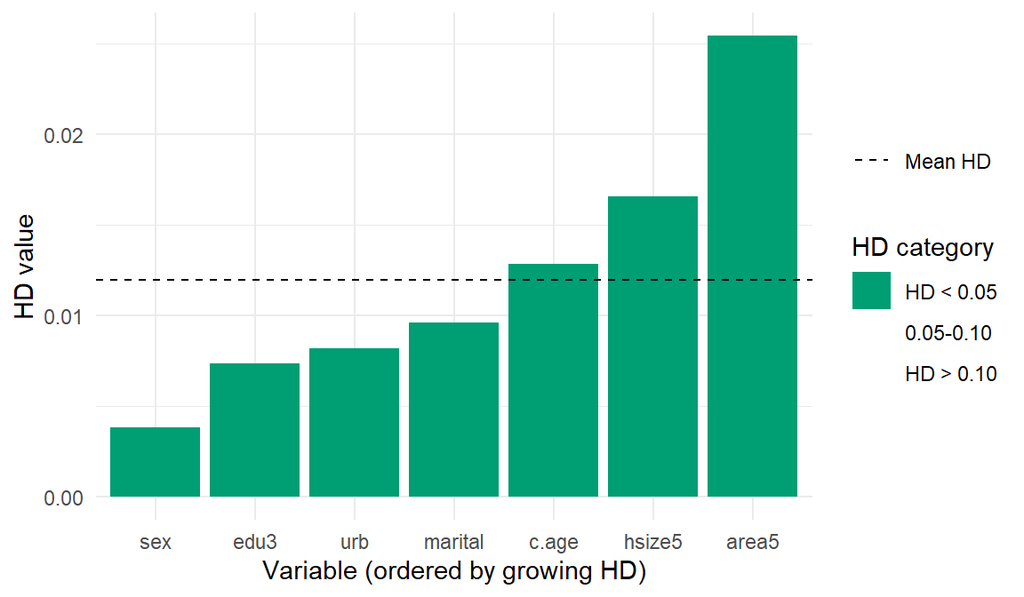

```r
hd.df <- data.frame(variable = names(hd.x), HD = as.numeric(hd.x))
hd.df$quality <- cut(hd.df$HD, c(-Inf, 0.05, 0.10, Inf),
                     labels = c("HD < 0.05", "0.05-0.10", "HD > 0.10"))
ggplot(hd.df, aes(x = reorder(variable, HD), y = HD, fill = quality)) +
  geom_col() +
  geom_hline(aes(yintercept = mean(HD), linetype = "Mean HD")) +
  scale_linetype_manual(values = c("Mean HD" = "dashed")) +
  scale_fill_manual(values = c("HD < 0.05" = "#009E73", "0.05-0.10" = "#E69F00",
                               "HD > 0.10" = "#0072B2"), drop = FALSE) +
  labs(x = "Variable (ordered by growing HD)", y = "HD value",
       fill = "HD category", linetype = NULL) +
  theme_minimal()
```

All the distances are **small** (between 0.004 for sex and 0.025 for area). From the point of view of QC6, any of the candidates can be used.

2. **Plot the distributions:** As additional check, plot the weighted distributions of A and B for age, education and household size.

**Hint: which code to use**

- Weighted shares: `prop.table(xtabs(ww ~ c.age, data = samp.A))`.
- Put the shares of both files and all variables in one data frame (columns: variable, category, file, share).
- `ggplot(...) + geom_col(position = "dodge") + facet_wrap(~ variable, scales = "free_x")`.

**Click here to show the solution**

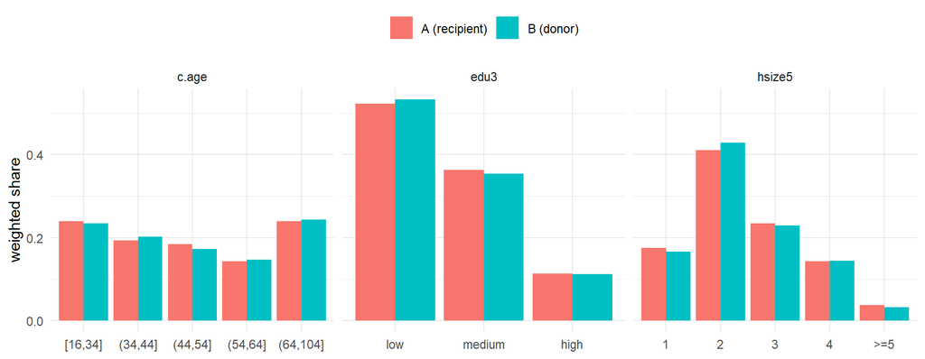

```r
long <- do.call(rbind, lapply(c("c.age", "edu3", "hsize5"), function(v) {
  pA <- prop.table(xtabs(as.formula(paste("ww ~", v)), samp.A))
  pB <- prop.table(xtabs(as.formula(paste("ww ~", v)), samp.B))
  data.frame(variable = v, category = rep(names(pA), 2),
             file = rep(c("A (recipient)", "B (donor)"), each = length(pA)),
             share = c(pA, pB[names(pA)]))
}))
long$category <- factor(long$category, levels = unique(long$category))
ggplot(long, aes(category, share, fill = file)) +
  geom_col(position = "dodge") +
  facet_wrap(~ variable, scales = "free_x") +
  labs(x = NULL, y = "weighted share", fill = NULL) +
  theme_minimal() + theme(legend.position = "top")
```

### 3.3.3 **QC7 - Association of X with Y and with Z**

The matching variables should be related to **both** Y and Z. Variables that predict neither only add noise and make donation classes smaller. A useful rule (D’Orazio et al., 2006): if $X_Y$ are the best predictors of Y and $X_Z$ those of Z, choose the matching variables $X_M$ such that

$$X_Y \cap X_Z \subseteq X_M \subseteq X_Y \cup X_Z$$

In plain words, this means that the matching variables should **at least** include the variables that are good predictors of **both** Y and Z (the intersection), and **at most** the variables that predict **either** Y or Z (the union). A variable that predicts neither should not be used. Within this range, prefer fewer variables (parsimony principle).

For categorical variables we use **Cramér’s V** ($0$ = no association, $1$ = perfect association). In social surveys V is often small. In a multivariate setting we can, for example, regress Y and Z on X.

`pw.assoc()` computes, for each X, several measures of association with a categorical response, using the survey weights:

**Click here to show the code**

```r
pZ <- pw.assoc(labour5 ~ area5 + urb + hsize5 + c.age + sex + marital + edu3,
               data = samp.B, weights = "ww", out.df = TRUE)
round(pZ[, c("V", "bcV", "norm.mi", "U", "AIC")], 3)
```

```
            V   bcV norm.mi     U       AIC
area5   0.106 0.103   0.015 0.015 18978.663
urb     0.044 0.036   0.002 0.001 19229.782
hsize5  0.102 0.099   0.015 0.014 18995.944
c.age   0.386 0.385   0.241 0.241 14635.039
sex     0.348 0.347   0.092 0.044 18396.240
marital 0.222 0.220   0.055 0.037 18540.025
edu3    0.222 0.221   0.053 0.035 18580.791
```

- `V` and `bcV`: Cramér’s V and its bias-corrected version;
- `norm.mi`: normalised mutual information; `U`: Theil’s uncertainty coefficient (both 0 = independence);
- `AIC`: of the model Z ~ X<sub>j</sub> (lower is better).

Age (V = 0.39) and sex (0.35) are the strongest predictors of labour status, followed by marital status and education (0.22). Urbanisation is almost unrelated (0.04).

#### 3.3.3.1 **Exercises**

1. **Association with Y:** Do the same for income classes `c.neti` in A. Then compute the average Cramér’s V of each variable over Y and Z. Which variables are related to both?

**Hint: which code to use**

- Same call as the solved example, with `c.neti` as response and `data = samp.A`.
- `rbind(Y = pY$V, Z = pZ$V)` puts the two rows of Cramér’s V together; `colMeans()` gives the average of each column.

**Click here to show the solution**

```r
pY <- pw.assoc(c.neti ~ area5 + urb + hsize5 + c.age + sex + marital + edu3,
               data = samp.A, weights = "ww", out.df = TRUE)
V <- rbind(Y.income = pY$V, Z.labour = pZ$V)
colnames(V) <- X.cand
V <- rbind(V, average = colMeans(V))
round(V[, order(-V["average", ])], 3)
```

```
           sex c.age  edu3 marital hsize5 area5   urb
Y.income 0.357 0.225 0.241   0.182  0.130 0.115 0.063
Z.labour 0.348 0.386 0.222   0.222  0.102 0.106 0.044
average  0.352 0.305 0.232   0.202  0.116 0.110 0.053
```

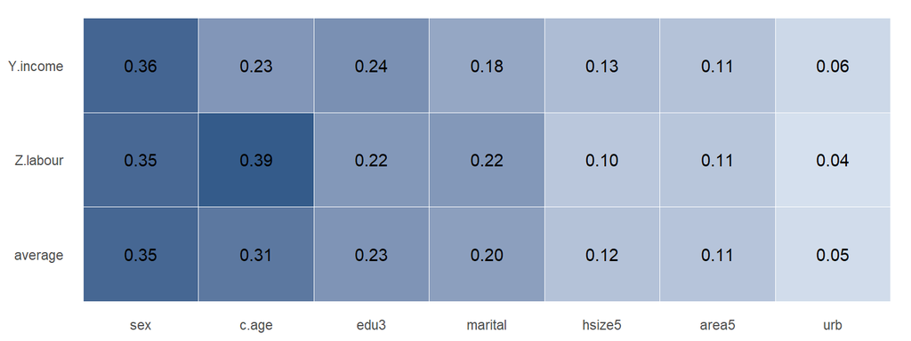

```r
cv <- as.data.frame(as.table(V))
names(cv) <- c("target", "x", "V")
cv$x <- factor(cv$x, levels = names(sort(V["average", ], decreasing = TRUE)))
cv$target <- factor(cv$target, levels = rev(rownames(V)))
ggplot(cv, aes(x, target, fill = V)) +
  geom_tile(colour = "white") +
  geom_text(aes(label = sprintf("%.2f", V))) +
  scale_fill_gradient(low = "#EAF2FB", high = "#1F4F80", limits = c(0, 0.42)) +
  labs(x = NULL, y = NULL) +
  theme_minimal() + theme(legend.position = "none", panel.grid = element_blank())
```

Sex (average V = 0.35), age (0.31), education (0.23) and marital status (0.20) are related to both targets. Area and household size are weak (around 0.11), urbanisation is negligible. All values are “moderate”, as is typical for social survey data.

2. **Your choice:** Based on QC5–QC7, which variables would you use for the matching?

**Possible solution**

The choice is not unique. Age, sex and education are related to both targets; marital status mainly predicts Z. Area is weak in bivariate terms, but it becomes relevant once the other variables are controlled for (see the regressions in “Going further”), and it is natural to borrow values from people living in the same area. Each extra variable makes the donation classes smaller (QC9): parsimony matters.

## 3.4 **Selecting the matching approach and matching**

### 3.4.1 **QC8 - The method should fit the measurement scale**

Our matching variables and Z are categorical (age in classes, sex, education) or ordinal. Nonparametric **hot deck** methods are a natural choice: they impute observed (“live”) values and do not need a model for Z (D’Orazio et al., 2006). With continuous variables, distance and rank hot deck or mixed methods are alternatives. Here we will try different methods to exercise more.

### 3.4.2 **QC9 - Donation classes**

Donation classes must not be empty: every recipient needs at least one donor in its class. Classes that are too small make the same donors be used again and again; classes that are too large make donors less similar to the recipients.

1. **Check the classes:** Count recipients and donors in each area (unweighted). Is any class empty? How many donors are there per recipient? What would happen with finer classes, e.g. age × sex × education × area?

**Hint: which code to use**

- Unweighted counts: `table(samp.A$area5)` and `table(samp.B$area5)`.
- For finer classes: `xtabs(~ c.age + sex + edu3 + area5, data = samp.B)`; `min()` gives the smallest class.

**Click here to show the solution**

```r
cl <- rbind(recipients = table(samp.A$area5), donors = table(samp.B$area5))
rbind(cl, donors.per.recipient = round(cl["donors", ] / cl["recipients", ], 1))
```

```
                         NE     NO      C    S     I
recipients            575.0  708.0  733.0  731 262.0
donors               1468.0 1555.0 1581.0 1465 617.0
donors.per.recipient    2.6    2.2    2.2    2   2.4
```

```r
## finer classes
a <- xtabs(~ c.age + sex + edu3 + area5, data = samp.A)
b <- xtabs(~ c.age + sex + edu3 + area5, data = samp.B)
c(classes = length(b), smallest.donor.class = min(b[a > 0]))
```

```
             classes smallest.donor.class
                 150                    1
```

The five areas contain between 617 and 1,581 donors, at least 2 per recipient. With age × sex × education × area there would be 150 classes, some with a single donor: the same donors would be reused many times. With area as the only class, age, sex and education are used in the **distance** within each area instead.

### 3.4.3 **Matching**

In this part we will practice with different methods.

**1. Random hot deck within fixed classes (age class × sex).** Each recipient receives a donor drawn at random, with equal probability, among the donors of the same age class and sex. There is no distance. The classes must not be empty (check it as in QC9).

**Click here to show the code (but first try it yourself!)**

```r
set.seed(1234)   # the donor is drawn at random: fix the seed to reproduce the results
out.rnd <- RANDwNND.hotdeck(data.rec = samp.A, data.don = samp.B,
                            don.class = c("c.age", "sex"))
fillA.rnd.1 <- create.fused(data.rec = samp.A, data.don = samp.B,
                            mtc.ids = out.rnd$mtc.ids, dup.x = TRUE,
                            match.vars = c("c.age", "sex"), z.vars = "labour5")
head(out.rnd$mtc.ids, 3)   # recipient id, donor id
```

```
     rec.id  don.id
[1,] "6301"  "15544"
[2,] "19567" "5489"
[3,] "10589" "32410"
```

**2. Random hot deck within non-fixed classes.** Within the classes education (`edu7`) × sex, the algorithm keeps the k = 5 donors closest in **age** (in years) and draws one of them at random. The “class” of each recipient is formed by its 5 nearest donors, so it changes from recipient to recipient.

**Click here to show the code (but first try it yourself!)**

```r
set.seed(1234)
out.rnd2 <- RANDwNND.hotdeck(data.rec = samp.A, data.don = samp.B,
                             don.class = c("edu7", "sex"),
                             match.vars = "age", cut.don = "exact", k = 5)
head(out.rnd2$sum.dist, 4)
```

```
     min max                sd cut dist.rd
[1,]   0  49 11.97574059220537   4       0
[2,]   0  58 17.13919917467451   1       1
[3,]   1  46 10.61782122396576   3       3
[4,]   0  42 11.17538323332039   1       1
```

```r
fillA.rnd.2 <- create.fused(data.rec = samp.A, data.don = samp.B,
                            mtc.ids = out.rnd2$mtc.ids, dup.x = TRUE,
                            match.vars = c("c.age", "sex"), z.vars = "labour5")
```

`sum.dist` describes, for each recipient, the distances (in years of age) to the donors of its class: minimum (`min`), maximum (`max`) and standard deviation (`sd`); `cut` is the distance of the 5th closest donor, and `dist.rd` the distance to the donor actually selected.

**3. Nearest neighbour distance hot deck, unconstrained.** Within the classes formed by sex, each recipient receives the donor **closest** in age (if several donors are equally close, one is chosen at random). A donor can be used more than once.

**Click here to show the code (but first try it yourself!)**

```r
set.seed(1234)
out.nnd1 <- NND.hotdeck(data.rec = samp.A, data.don = samp.B,
                        don.class = "sex", match.vars = "age")
summary(out.nnd1$dist.rd)   # distance (years of age) between recipient and donor
```

```
              Min.            1st Qu.             Median               Mean
0.0000000000000000 0.0000000000000000 0.0000000000000000 0.0006646726487205
           3rd Qu.               Max.
0.0000000000000000 1.0000000000000000
```

```r
fillA.nnd.1 <- create.fused(data.rec = samp.A, data.don = samp.B,
                            mtc.ids = out.nnd1$mtc.ids, dup.x = TRUE,
                            match.vars = c("age", "sex"), z.vars = "labour5")
```

**4. Nearest neighbour distance hot deck, constrained.** Each donor can be used **only once**. The donors are assigned so that the **total** distance over all recipients is as small as possible (Hungarian algorithm, package `clue`). This needs at least as many donors as recipients in each class.

**Click here to show the code (but first try it yourself!)**

```r
out.nnd2 <- NND.hotdeck(data.rec = samp.A, data.don = samp.B,
                        don.class = "sex", match.vars = "age",
                        constrained = TRUE, k = 1, constr.alg = "hungarian")
summary(out.nnd2$dist.rd)
```

```
             Min.           1st Qu.            Median              Mean
0.000000000000000 0.000000000000000 0.000000000000000 0.001329345297441
          3rd Qu.              Max.
0.000000000000000 1.000000000000000
```

```r
summary(out.nnd1$dist.rd)
```

```
              Min.            1st Qu.             Median               Mean
0.0000000000000000 0.0000000000000000 0.0000000000000000 0.0006646726487205
           3rd Qu.               Max.
0.0000000000000000 1.0000000000000000
```

```r
fillA.nnd.2 <- create.fused(data.rec = samp.A, data.don = samp.B,
                            mtc.ids = out.nnd2$mtc.ids, dup.x = TRUE,
                            match.vars = c("age", "sex"), z.vars = "labour5")
```

For almost all recipients the donor has exactly the same age (median distance 0). The mean distance is 0.0007 years without the constraint and 0.0013 with it: only a handful of recipients receive a donor one year older or younger. The constraint costs very little here, because there are more than twice as many donors as recipients.

**5. Try out your own model!**, peraphs on the decisions we took before (e.g. recoding on variables etc.). Choose the variables and the method you prefer. How are the results?

**6. Compare the models** (also with reference to the follwing criteria).

## 3.5 **Post-matching: QC11–QC13**

After the matching, the distribution of Z in the recipient should be similar to its distribution in the donor (**QC11**), and so should the distribution of Z within the categories of the common variables (**QC12**). We compare the weighted distributions with the Hellinger distance, now with `ref = TRUE`: the donor is the reference.

As a solved example we evaluate the simplest synthetic file, `fillA.rnd.1` (random hot deck within age class × sex, method 1).

**Click here to show the code**

```r
## QC11: Hellinger distance
t.imp <- xtabs(ww ~ labour5, data = fillA.rnd.1)
t.don <- xtabs(ww ~ labour5, data = samp.B)
comp.prop(p1 = t.imp, p2 = t.don, n1 = nrow(fillA.rnd.1), ref = TRUE)$meas
```

```
                tvd             overlap               Bhatt                Hell
0.01925939205424229 0.98074060794575768 0.99974585110771519 0.01594204793258417
```

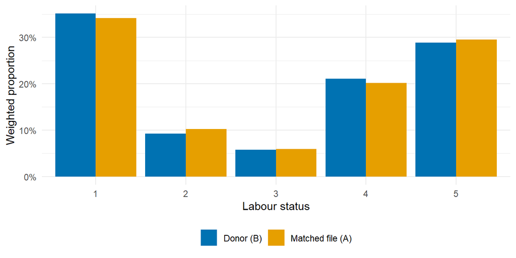

```r
## QC11: weighted proportions with 95% confidence intervals
d.don <- svydesign(ids = ~1, weights = ~ww, data = samp.B)
d.mtc <- svydesign(ids = ~1, weights = ~ww, data = fillA.rnd.1)
props <- function(design, label) {
  m <- svymean(~ labour5, design)
  ci <- confint(m)
  data.frame(category = sub("labour5", "", names(coef(m))), prop = coef(m),
             lower = ci[, 1], upper = ci[, 2], file = label)
}
p11 <- rbind(props(d.don, "Donor (B)"), props(d.mtc, "Matched file (A)"))
ggplot(p11, aes(category, prop, fill = file)) +
  geom_col(position = position_dodge(0.9)) +
  scale_y_continuous(labels = scales::percent) +
  scale_fill_manual(values = c("Donor (B)" = "#0072B2", "Matched file (A)" = "#E69F00")) +
  labs(x = "Labour status", y = "Weighted proportion", fill = NULL) +
  theme_minimal() + theme(legend.position = "bottom")
```

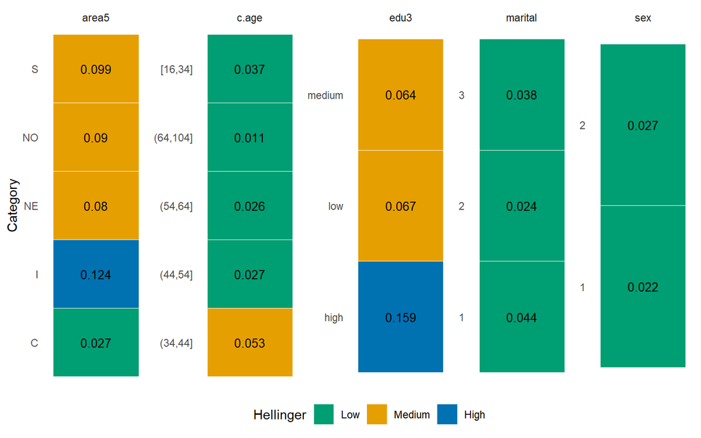

```r
## QC12: Hellinger distance between the distributions of Z within each category of X
hd.by.group <- function(x, fused) {
  dm  <- svydesign(ids = ~1, weights = ~ww, data = fused)
  t.d <- svytable(as.formula(paste("~", x, "+ labour5")), d.don)
  t.m <- svytable(as.formula(paste("~", x, "+ labour5")), dm)
  do.call(rbind, lapply(rownames(t.d), function(l) data.frame(
    group_var = x, group_level = l,
    HD = comp.prop(p1 = t.m[l, ], p2 = t.d[l, ], n1 = sum(fused[[x]] == l),
                   ref = TRUE)$meas["Hell"])))
}
hd12 <- do.call(rbind, lapply(c("c.age", "sex", "edu3", "area5", "marital"),
                              hd.by.group, fused = fillA.rnd.1))
hd12$category <- cut(hd12$HD, c(-Inf, 0.05, 0.10, Inf), labels = c("Low", "Medium", "High"))

ggplot(hd12, aes(group_var, group_level, fill = category)) +
  geom_tile(colour = "white") +
  geom_text(aes(label = round(HD, 3)), size = 3.5) +
  facet_wrap(~ group_var, scales = "free", nrow = 1) +
  scale_fill_manual(values = c(Low = "#009E73", Medium = "#E69F00", High = "#0072B2"),
                    drop = FALSE, name = "Hellinger") +
  labs(x = NULL, y = "Category") +
  theme_minimal() +
  theme(panel.grid = element_blank(), legend.position = "bottom", axis.text.x = element_blank())
```

- **QC11**: the distribution of labour status is well preserved (HD = 0.016); the confidence intervals overlap for every category.
- **QC12**: within the categories of age and sex, the matching variables, the distribution of labour status is close to the donor (HD between 0.011 and 0.053). Within education and area, which method 1 does not use, the distances are much larger: up to 0.16 for high education and 0.12 for the Islands. What you do not match on is not preserved. Marital status, also not used, stays below 0.05, probably because it is closely related to age.

#### 3.5.0.1 **Exercises**

1. **Try the other methods:** Repeat QC11 and QC12 for the other synthetic files (`fillA.rnd.2`, `fillA.nnd.1`, `fillA.nnd.2`), or for a matching of your own choice (other donation classes, other matching variables, another distance). Which method preserves the distributions best? Does the result agree with the comparison of the methods in the matching section?

### 3.5.1 **QC13 - Documentation**

Document every choice, so that others can assess and reproduce the matching: sources, harmonisation, matching variables and why they were chosen, method and parameters (donation classes, distance, weights, seed), software and version, quality indicators and the assumptions made. See the checklist at the end of this document.

#### 3.5.1.1 **Exercises**

1. **Fill in the checklist** for the solved example.

| Criterion | What you checked | Result / decision |
| --- | --- | --- |
| QC1 same target population |  |  |
| QC2 comparable common variables |  |  |
| QC3 harmonised measurement |  |  |
| QC4 temporal alignment |  |  |
| QC5 sparse / missing categories |  |  |
| QC6 similar marginals (HD) |  |  |
| QC7 X associated with Y and Z |  |  |
| QC8 method fits measurement scale |  |  |
| QC9 donation classes |  |  |
| QC10 uncertainty (Fréchet bounds) |  |  |
| QC11 marginal of Z preserved |  |  |
| QC12 joint distributions preserved |  |  |
| QC13 documentation |  |  |

**Click here to show the solution (solved example: method 1, `fillA.rnd.1`)**

| Criterion | What we checked | Result / decision |
| --- | --- | --- |
| QC1 | Estimated population sizes, age range | Comparable (5.09 vs. 5.16 million; aged 17+ in both) |
| QC2 | List and coding of common variables | 9 common variables, identical factor levels |
| QC3 | Categories (questionnaires in a real application) | Already harmonised (artificial data) |
| QC4 | Reference period | Same period (artificial data) |
| QC5 | Unweighted frequencies, missing values | No missing values; `edu7` collapsed into 3 groups (`edu3`) |
| QC6 | Hellinger distances, plot | All HD ≤ 0.025 (small) |
| QC7 | Cramér’s V (weighted) | Sex, age, education and marital status related to both Y and Z. Method 1 uses only **age class and sex** |
| QC8 | Variable types | Categorical matching variables and Z → random hot deck within donation classes |
| QC9 | Recipients and donors per class (unweighted) | 10 classes (age class × sex), none empty; 514–947 donors per class, 2.0–2.5 donors per recipient |
| QC10 | Fréchet bounds (see “Going further”) | Average width 0.114 without X; 0.077 given age class × sex; 0.063 given area, age, sex and education. Still wide: the Y × Z table depends on the CIA |
| QC11 | HD of labour status, weighted proportions with 95% CIs | HD = 0.016; the confidence intervals overlap for every category |
| QC12 | HD of labour status within each category of X | Age and sex (matching variables): 0.011–0.053; marital status ≤ 0.044. Education (0.064–0.159) and area (0.027–0.124), not used in the matching, are **not** preserved |
| QC13 | Software, settings | StatMatch 1.4.3, `RANDwNND.hotdeck()`, donation classes `c.age` × `sex`, no distance, donors drawn with equal probability (no `weight.don`), `set.seed(1234)`; CIA assumed |

## 3.6 **Going further (for your own study)**

The following techniques are part of a complete matching analysis but go beyond this introductory session. We give sample code with short comments; see the references for details.

### 3.6.1 **QC10: How uncertain is the Y × Z table? Fréchet bounds**

Because Y and Z are never observed together, A and B do not identify their joint distribution: many Y × Z tables are compatible with the data, and the matching reproduces only one of them, the one implied by the CIA. The **Fréchet bounds** give, for each cell of the Y × Z table, the smallest and the largest probability compatible with the data. Using the matching variables (conditional bounds) makes the intervals narrower. Wide intervals mean that the results depend mainly on the CIA.

The function needs tables with **counts**, so the weights are rescaled to sum to the sample sizes (with weights summing to 1, every cell would look empty). `align.margins = TRUE` needs the package `mipfp`.

```r
samp.A$wwn <- samp.A$ww / sum(samp.A$ww) * nrow(samp.A)
samp.B$wwn <- samp.B$ww / sum(samp.B$ww) * nrow(samp.B)

txx <- xtabs(wwn ~ area5 + c.age + sex + edu3, data = samp.A) +
       xtabs(wwn ~ area5 + c.age + sex + edu3, data = samp.B)
txy <- xtabs(wwn ~ area5 + c.age + sex + edu3 + c.neti, data = samp.A)
txz <- xtabs(wwn ~ area5 + c.age + sex + edu3 + labour5, data = samp.B)

fb <- Frechet.bounds.cat(tab.x = txx, tab.xy = txy, tab.xz = txz,
                         print.f = "data.frame", align.margins = TRUE)
fb$uncertainty      ## average width: unconditional (av.u) and conditional on X (av.cx)
```

```
               av.u               av.cx
0.11380080870483349 0.06274776721320555
```

```r
head(fb$bounds, 3)  ## bounds and CIA estimate for each cell
```

```
    c.neti labour5 low.u               low.cx                 CIA
1 (-Inf,0]       1     0 0.002205207232418691 0.06063893655422959
2   (0,10]       1     0 0.003304864216085601 0.05552164289034454
3  (10,15]       1     0 0.003285370859906054 0.05458268375331059
               up.cx               up.u
1 0.1175093275260913 0.1937787291869313
2 0.1137004527175866 0.2235263396634939
3 0.1125963996320156 0.1775353773097402
```

The average width falls from 0.114 (no X) to 0.063 with the matching variables: still wide. For example, the share of the unemployed with low income could be very different from the 48% implied by the CIA.

### 3.6.2 **Selecting the matching variables by uncertainty**

D’Orazio, Di Zio & Scanu (2017) select the matching variables that make the Fréchet bounds narrowest, with a penalty for sparse tables:

```r
fx  <- "area5 + urb + hsize5 + c.age + sex + marital + edu3"
unc <- selMtc.by.unc(
  tab.x  = xtabs(as.formula(paste("wwn ~", fx)), data = samp.A) +
           xtabs(as.formula(paste("wwn ~", fx)), data = samp.B),
  tab.xy = xtabs(as.formula(paste("wwn ~", fx, "+ c.neti")),  data = samp.A),
  tab.xz = xtabs(as.formula(paste("wwn ~", fx, "+ labour5")), data = samp.B),
  corr.d = 2)
unc$av.df[, c("x.vars", "nc0.xy", "avw", "penalty", "avw.pen")]   ## last row: selected set
```

```
                x.vars nc0.xy                 avw               penalty
1                 <NA>      0 0.11380080870483349 0.0000000000000000000
2                c.age      0 0.08714187125955154 0.0003362474781439139
3            c.age*sex      0 0.07735920901052426 0.0003402517863218782
4       c.age*sex*edu3      9 0.07253596582382513 0.0003572704537334762
5 c.age*sex*edu3*area5    320 0.06290580949896087 0.0005104645227156713
              avw.pen
1 0.11380080870483349
2 0.08747811873769545
3 0.07769946079684614
4 0.07289323627755860
5 0.06341627402167653
```

The procedure selects age, sex, education and area, the variables used in this session.

### 3.6.3 **Design-based tests and multivariate checks (QC7)**

```r
dA <- svydesign(ids = ~1, weights = ~ww, data = samp.A)
dB <- svydesign(ids = ~1, weights = ~ww, data = samp.B)
svychisq(~ labour5 + c.age, design = dB)   ## Rao-Scott adjusted chi-square test
```

```
    Pearson's X^2: Rao & Scott adjustment

data:  svychisq(~labour5 + c.age, design = dB)
F = 178.4206956043, ndf = 15.575024629085, ddf = 104119.039645435550,
p-value < 2.2204460493e-16
```

```r
## weighted logistic regressions of binary versions of Y and Z on all candidate X
dA <- update(dA, low  = as.numeric(c.neti %in% c("(-Inf,0]", "(0,10]")))
dB <- update(dB, empl = as.numeric(labour5 %in% c("1", "2")))
mY <- svyglm(low  ~ c.age + sex + edu3 + marital + area5 + urb + hsize5,
             design = dA, family = quasibinomial())
mZ <- svyglm(empl ~ c.age + sex + edu3 + marital + area5 + urb + hsize5,
             design = dB, family = quasibinomial())
round(exp(cbind(OR.low.income = coef(mY), OR.employed = coef(mZ))), 2)
```

```
              OR.low.income        OR.employed
(Intercept)            0.70 1.5800000000000001
c.age(34,44]           0.26 3.0800000000000001
c.age(44,54]           0.24 3.1699999999999999
c.age(54,64]           0.24 0.6000000000000000
c.age(64,104]          0.41 0.0300000000000000
sex2                   5.52 0.3000000000000000
edu3medium             0.38 2.0800000000000001
edu3high               0.15 3.9399999999999999
marital2               0.75 1.3799999999999999
marital3               0.52 1.2000000000000000
area5NO                0.97 1.1399999999999999
area5C                 1.25 0.9800000000000000
area5S                 2.13 0.4800000000000000
area5I                 3.05 0.4500000000000000
urb2                   0.92 1.1899999999999999
urb3                   0.87 1.2500000000000000
hsize52                1.65 0.6800000000000000
hsize53                1.94 0.4700000000000000
hsize54                2.15 0.5600000000000001
hsize5>=5              1.68 0.4100000000000000
```

With real survey designs, declare clusters and strata in `svydesign()`. Area, weak in bivariate terms, matters once the other variables are controlled for: people in the South and the Islands have higher odds of a low income (OR 2.1 and 3.1) and lower odds of being employed (OR 0.48 and 0.45) than people in the North-East. `regTermTest(mY, ~ area5)` tests the variable as a whole.

### 3.6.4 **Other matching methods**

```r
## rank hot deck: match on the position of age in the weighted distribution of each file
out.rk <- rankNND.hotdeck(data.rec = samp.A, data.don = samp.B, var.rec = "age",
                          don.class = c("edu3", "sex"), weight.rec = "ww", weight.don = "ww")

## distance hot deck with several mixed-type matching variables (Gower distance)
out.gw <- NND.hotdeck(data.rec = samp.A, data.don = samp.B, don.class = "area5",
                      match.vars = c("c.age", "sex", "edu3", "marital"), dist.fun = "Gower")
```

Each result is turned into a synthetic file with `create.fused()` and evaluated with QC11–QC12 as above. Rank hot deck is useful when a variable is measured on different scales in the two surveys: it matches units in the same position of the distribution (see `?rankNND.hotdeck`). `NND.hotdeck()` does not use the survey weights.

## 3.7 **Key take-aways**

**Key take-aways**

- Before matching, check that the two surveys cover the same population, measure the common variables in the same way and refer to the same period (QC1–QC4).
- Choose few matching variables that are coherent across the files (QC6) and related to **both** Y and Z (QC7). Recode sparse categories (QC5) and check the donation classes (QC9).
- Use the survey weights: in the comparison of distributions and in the selection of donors.
- Post-matching checks (QC11–QC12) are **necessary but not sufficient**: they cannot see the relationship between Y and Z.
- Without auxiliary information, every method assumes the CIA; when X is only moderately related to Y and Z, the Y–Z association is attenuated. The uncertainty analysis (QC10) shows how much the results depend on it.
- Document every choice (QC13).

## 3.8 **References**

- Andridge, R. R., & Little, R. J. (2010). A review of hot deck imputation for survey non-response. *International Statistical Review*, 78(1), 40–64.
- D’Orazio, M. StatMatch: Statistical Matching or Data Fusion. R package. https://CRAN.R-project.org/package=StatMatch
- D’Orazio, M., Di Zio, M., & Scanu, M. (2006). *Statistical Matching: Theory and Practice*. Wiley.
- D’Orazio, M., Di Zio, M., & Scanu, M. (2017). The use of uncertainty to choose matching variables in statistical matching. *International Journal of Approximate Reasoning*, 90, 433–440.
- Leulescu, A., & Agafitei, M. (2013). *Statistical matching: A model based approach for data integration*. Eurostat Methodologies and Working Papers.
- Moretti, A., Salvatore, C., & Kraemer, F. Data integration via statistical matching: A user-oriented quality framework (manuscript under review).
- Rubin, D. B. (1987). *Multiple Imputation for Nonresponse in Surveys*. Wiley.